# Water Data Exploration

Badhia Yunes Katz

August 2025

## Overview

### USGS - Flow

#### Main stream Klamath

- 11509500 - Klamath River at Keno Or
- 11510700 - Klamath River Below John C Boyle Powerplant
- 11516530 - Klamath River Below Iorngate Dam
- 11520500 - Klamath River Nr Seiad Valley CA
- 11523000 - Klamath River A Orleans
- 11530500 - Klamath River Near Klamath (Furthest Downstream)

##### Date coverage

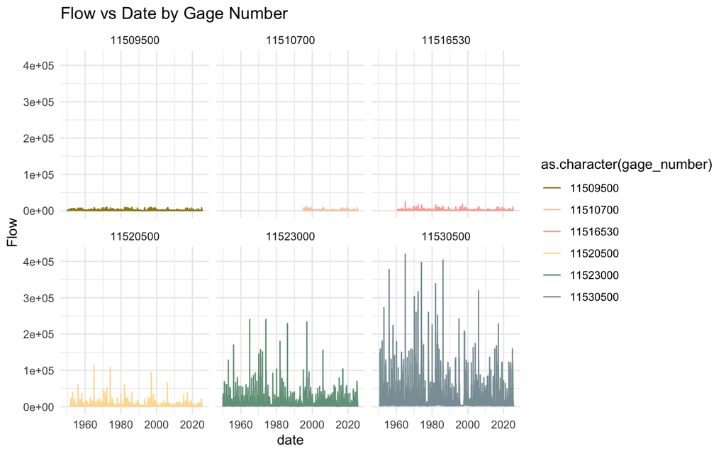

##### Date range summary

```
#> # A tibble: 6 × 4
#>   gage_number min_date   max_date   record_count
#>   <chr>       <date>     <date>            <int>
#> 1 11509500    1950-01-01 2025-08-25        27631
#> 2 11510700    1995-01-01 2025-08-25        11195
#> 3 11516530    1960-10-01 2025-08-25        23705
#> 4 11520500    1951-10-01 2025-08-25        26993
#> 5 11523000    1950-01-01 2025-08-25        27630
#> 6 11530500    1950-10-01 2025-08-24        26646
```

#### Trinity

Potential gages

- 11528700 SF TRINITY R BL HYAMPOM CA - South fork
- 11530000 TRINITY R A HOOPA CA
- 11523200 TRINITY R AB COFFEE C NR TRINITY CENTER CA
- 11525500 TRINITY R A LEWISTON CA
- 11525655 TRINITY R BL LIMEKILN GULCH NR DOUGLAS CITY CA
- 11525854 TRINITY R A DOUGLAS CITY CA
- 11526250 TRINITY R A JUNCTION CITY CA
- 11526400 TRINITY R AB NF TRINITY R NR HELENA CA
- 11527000 TRINITY R NR BURNT RANCH CA

##### Date coverage per gage

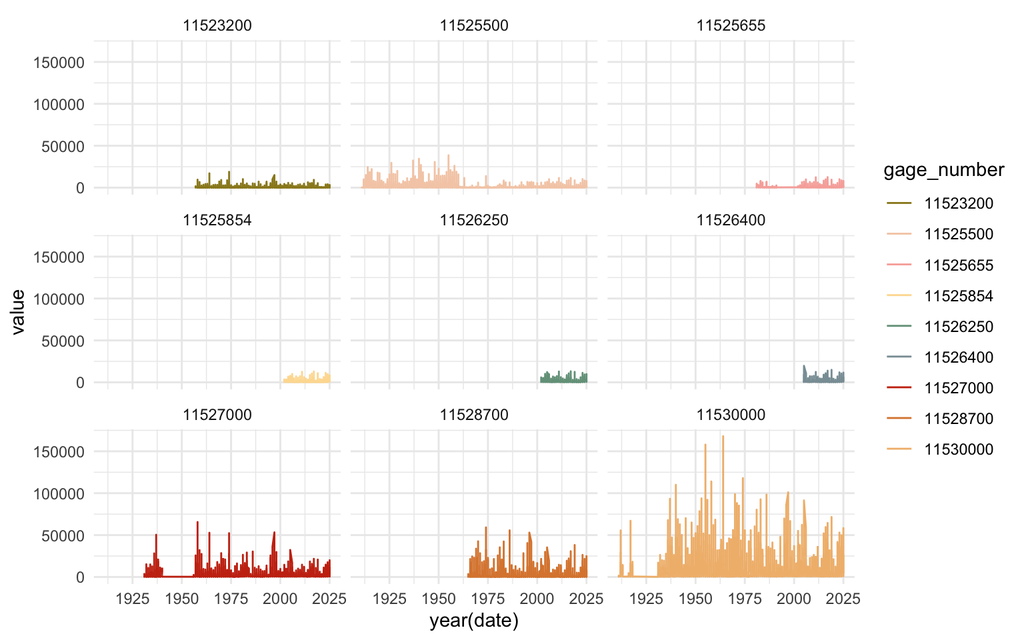

##### Date range summary

```
#> # A tibble: 9 × 4
#>   gage_number min_date   max_date   record_count
#>   <chr>       <date>     <date>            <int>
#> 1 11523200    1957-10-01 2025-08-25        24798
#> 2 11525500    1911-10-01 2025-08-25        41603
#> 3 11525655    1981-04-28 2025-08-25        12173
#> 4 11525854    2002-10-01 2025-08-25         8365
#> 5 11526250    2002-10-01 2025-08-25         8365
#> 6 11526400    2005-03-29 2025-08-25         7455
#> 7 11527000    1931-10-01 2025-08-25        28453
#> 8 11528700    1965-10-01 2025-08-25        21879
#> 9 11530000    1911-10-01 2025-08-25        35757
```

#### Scott

- 11519500 SCOTT R NR FORT JONES CA

##### Date coverage

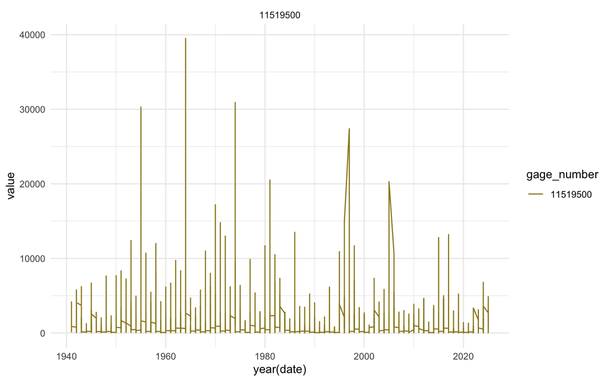

##### Date range summary

```
#> # A tibble: 1 × 4
#>   gage_number min_date   max_date   record_count
#>   <chr>       <date>     <date>            <int>
#> 1 11519500    1941-10-01 2025-08-25        30645
```

#### Shasta

- Shasta R NR Montague CA - 11517000
- Shasta R NR Yreka CA - 11517500

##### Date coverage plot

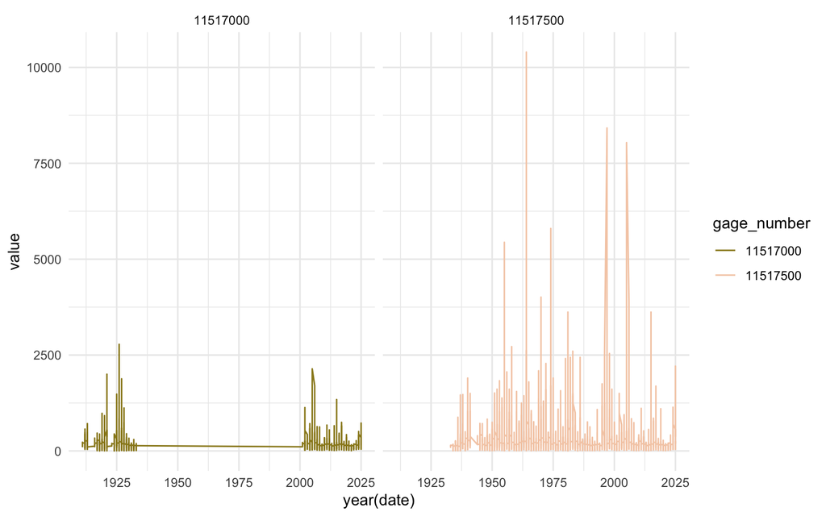

##### Date range summary

```
#> # A tibble: 2 × 4
#>   gage_number min_date   max_date   record_count
#>   <chr>       <date>     <date>            <int>
#> 1 11517000    1911-10-01 2025-08-25        14937
#> 2 11517500    1933-10-01 2025-08-25        32489
```

#### Salmon

- 11522500 SALMON R A SOMES BAR CA

##### Date coverage plot

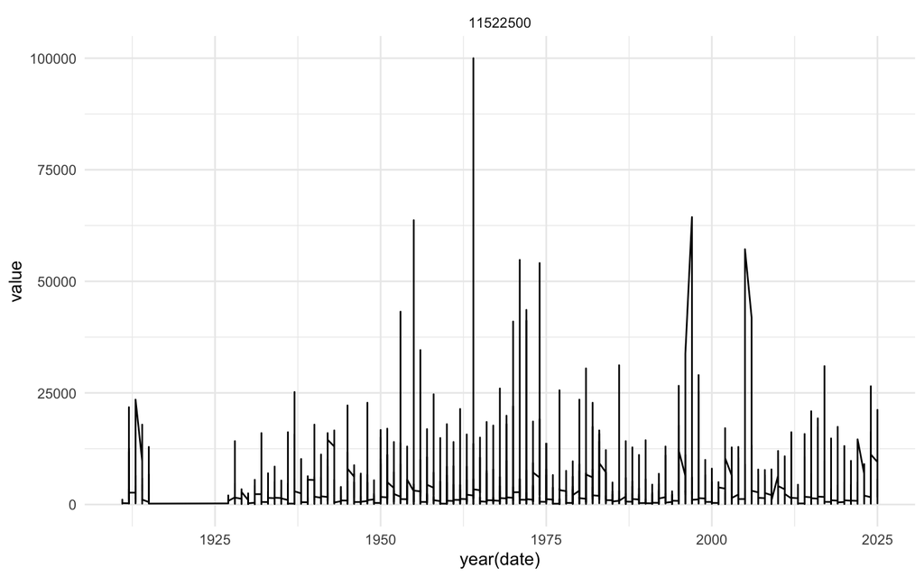

##### Date range summary

```
#> # A tibble: 1 × 4
#>   gage_number min_date   max_date   record_count
#>   <chr>       <date>     <date>            <int>
#> 1 11522500    1911-10-01 2025-08-25        37219
```

#### Indian Creek

List of USGS gages in Klamath watershed:

- Indian C NR Douglas City CA - 11525670
- Indian C NR Happy Camp CA - 11521500

##### Date coverage

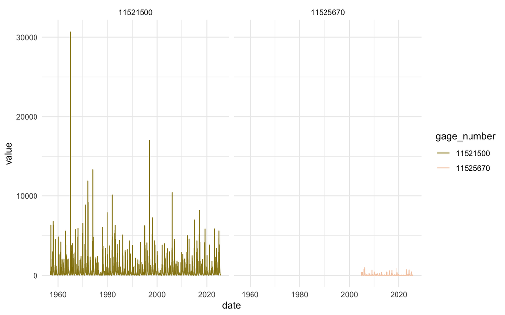

#### Other streams - Oregon

- Klamath Straits Drain Near Worden, OR - 11509340
- Ady Canal Above Lower Klamath Nwr, Near Worden, OR - 11509250
- North Canal at Highway 97, Near Midland, OR - 11509105
- Link River at Klamath Falls, OR - 11507500
- Williamson River Blw Sprague River NR Chiloquin,or - 11502500
- Crystal Creek Near Rocky Point, OR - 11504270 - NODATA
- Fourmile Canal Near Klamath Agency, OR - 11504260
- Sevenmile Cnl at Dike RD Br, NR Klamath Agency, OR - 11504290

##### Date coverage

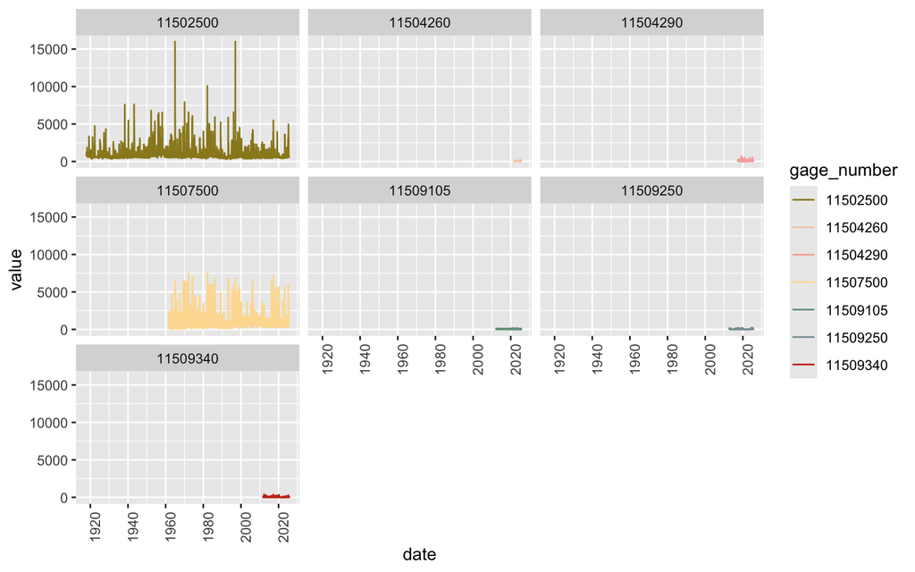

##### Date range summary

```
#> # A tibble: 7 × 4
#>   gage_number min_date   max_date   record_count
#>   <chr>       <date>     <date>            <int>
#> 1 11502500    1917-10-01 2025-08-25        39077
#> 2 11504260    2021-08-05 2025-08-25         1481
#> 3 11504290    2017-05-04 2025-08-25         3036
#> 4 11507500    1961-10-01 2025-08-25        23340
#> 5 11509105    2012-02-29 2025-08-25         4927
#> 6 11509250    2012-09-30 2025-08-25         4711
#> 7 11509340    2011-10-31 2025-08-25         5048
```

### USGS - Temperature

#### Main stream Klamath

- LINK RIVER AT KLAMATH FALLS, OR 11507500
- KLAMATH RIVER BLW JOHN C.BOYLE PWRPLNT, NR KENO,OR 11510700
- KLAMATH R NR KLAMATH CA 11530500
- KLAMATH R A ORLEANS 11523000
- KLAMATH RIVER AT KENO, OR 11509500
- KLAMATH RIVER ABOVE KENO DAM, AT KENO, OR 11509370
- KLAMATH RIVER ABV KENO DAM, AT KENO - BOTTOM 420741121554001
- KLAMATH STRAITS DRAIN NEAR HIGHWAY 97, OR 420451121510000
- KLAMATH STRAITS DRAIN ABOVE F-FF PUMPS, WORDEN, OR 420448121503100
- KLAMATH RIVER AT MILLER ISLAND BOAT RAMP, OR 420853121505500
- KLAMATH RIVER AT MILLER ISLAND BOAT RAMP-BOTTOM 420853121505501

##### Date coverage

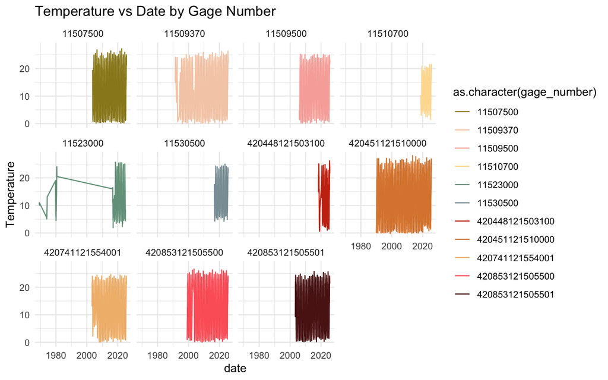

##### Date range summary

```
#> # A tibble: 11 × 4
#>    gage_number     min_date   max_date   record_count
#>    <chr>           <date>     <date>            <int>
#>  1 11507500        2003-09-30 2025-08-25         7914
#>  2 11509370        1991-05-24 2025-08-25        10541
#>  3 11509500        2005-12-21 2025-08-25         7060
#>  4 11510700        2018-11-01 2025-08-25         2485
#>  5 11523000        1969-04-06 2025-08-25         3202
#>  6 11530500        2016-10-01 2025-08-25         3236
#>  7 420448121503100 2018-05-12 2025-08-25         2256
#>  8 420451121510000 1989-12-29 2025-08-13        11297
#>  9 420741121554001 2003-05-16 2025-08-25         7363
#> 10 420853121505500 1999-02-06 2025-08-13         8945
#> 11 420853121505501 2003-05-01 2025-08-13         7964
```

#### Trinity

- TRINITY R AB NF TRINITY R NR HELENA CA 11526400
- TRINITY R A HOOPA CA 11530000

##### Date coverage

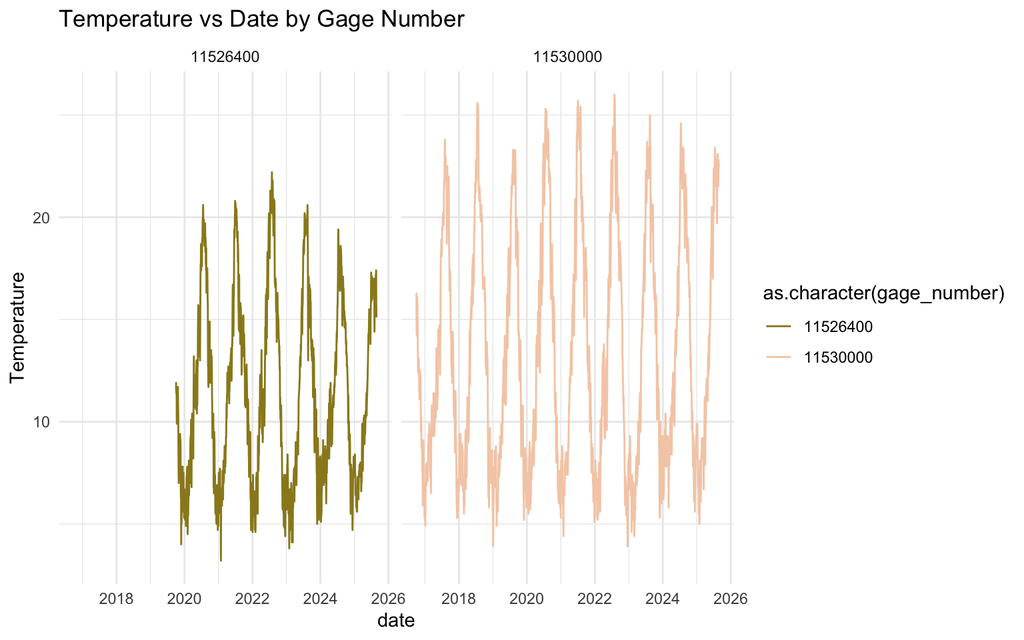

##### Date range summary

```
#> # A tibble: 2 × 4
#>   gage_number min_date   max_date   record_count
#>   <chr>       <date>     <date>            <int>
#> 1 11526400    2019-10-01 2025-08-25         2143
#> 2 11530000    2016-10-01 2025-08-25         3230
```

#### Klamath Upper Lake

- RATTLESNAKE POINT - RPT 422042121513100
- UPPER KLAMATH LAKE AT HOWARD BAY, OR 421935121551200
- MID-TRENCH - LOWER - MDTL 422305121553800
- MID-TRENCH - UPPER - MDTU 422305121553803
- SHOALWATER BAY - SHB 422444121580400
- MID-NORTH - LOWER - MDNL 422622122004000
- MID-NORTH - UPPER - MDNU 422622122004003
- WILLIAMSON RIVER OUTLET - WMR 422719121571400
- SEVENMILE CNL AT DIKE RD BR, NR KLAMATH AGENCY, OR 11504290

##### Date coverage

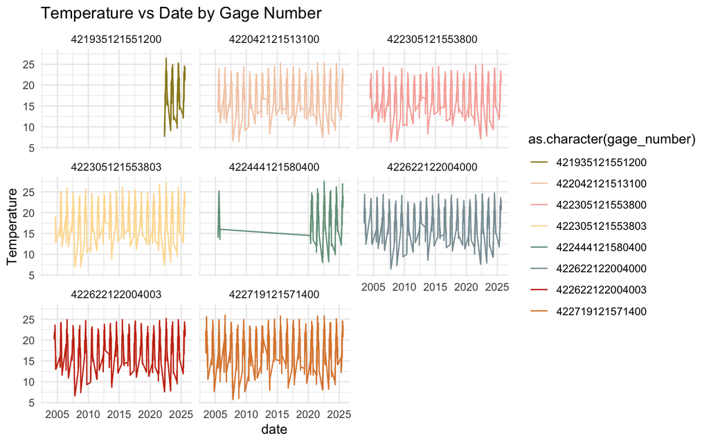

##### Date range summary

```
#> # A tibble: 8 × 4
#>   gage_number     min_date   max_date   record_count
#>   <chr>           <date>     <date>            <int>
#> 1 421935121551200 2022-04-22 2025-08-12          617
#> 2 422042121513100 2005-06-02 2025-08-12         3101
#> 3 422305121553800 2004-06-18 2025-08-12         3164
#> 4 422305121553803 2004-09-02 2025-08-12         3107
#> 5 422444121580400 2005-06-03 2025-08-12         1058
#> 6 422622122004000 2003-06-27 2025-08-24         3301
#> 7 422622122004003 2004-06-24 2025-08-25         3187
#> 8 422719121571400 2003-06-07 2025-08-12         3331
```

#### Lost River

- LOST RVR AT ANDERSON ROSE DVRSN DAM AT MALONE, OR 420037121334100
- LOST RVR BLW ANDERSON ROSE DVRSN DAM AT MALONE, OR 420036121333700
- LOST RIVER AT WILSON DAM, AT HENLEY, OR 420833121402000
- LOST R AT BR XING BLW HARPOLD DAM, NR BONANZA, OR 421010121271200
- LOST RIVER DIVERSION CHANNEL NR KLAMATH RIVER, OR 421015121471800
- LOST RIVER AT STATELINE ROAD, NR HATFIELD, CA 415954121312100

##### Date coverage

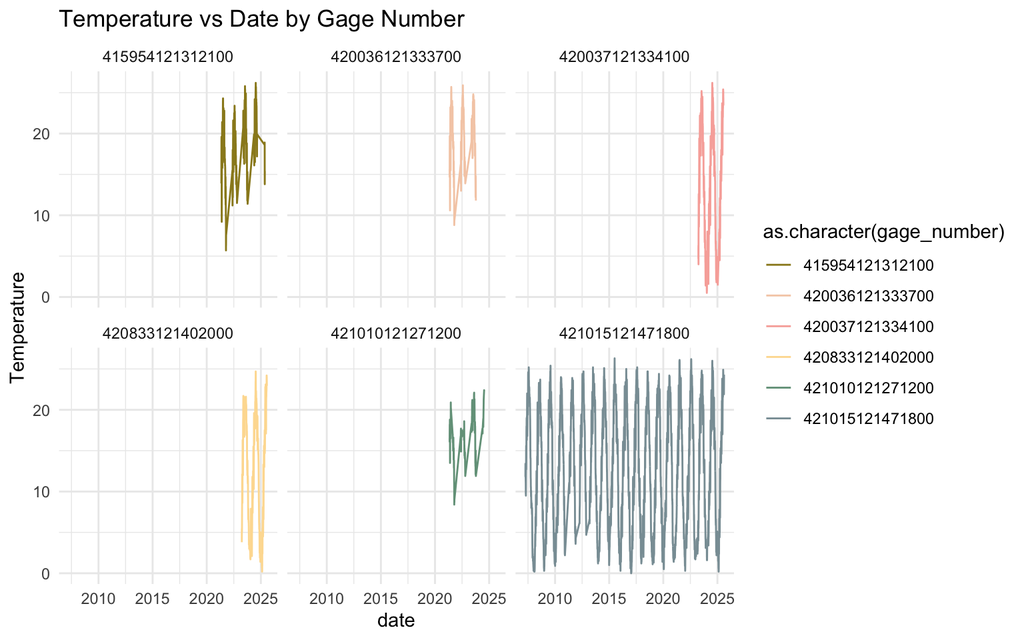

##### Date range summary

```
#> # A tibble: 6 × 4
#>   gage_number     min_date   max_date   record_count
#>   <chr>           <date>     <date>            <int>
#> 1 415954121312100 2021-05-07 2025-05-15          584
#> 2 420036121333700 2021-05-07 2023-10-12          458
#> 3 420037121334100 2023-03-30 2025-07-24          757
#> 4 420833121402000 2023-03-30 2025-07-24          795
#> 5 421010121271200 2021-05-07 2024-07-17          308
#> 6 421015121471800 2007-04-05 2025-08-13         6267
```

#### Other streams

- SPRAGUE RIVER NEAR CHILOQUIN, OR 11501000
- WILLIAMSON RIVER BLW SPRAGUE RIVER NR CHILOQUIN,OR 11502500
- WOOD RIVER NEAR KLAMATH AGENCY, OR 11504115
- FOURMILE CANAL NEAR KLAMATH AGENCY, OR 11504260
- KLAMATH R AB FALL C NR COPCO CA 11511990
- LINK RIVER BELOW KENO CANAL, NEAR KLAMATH FALLS,OR 11507501
- JACKSON CREEK NEAR LENZ, OR 11491470
- IRVING CREEK NEAR LENZ, OR 11491450
- LINK RIVER DAM 421401121480900
- SAND CREEK BLW SAND CREEK CANAL NR CHINCHALO, OR 11492550

##### Date coverage

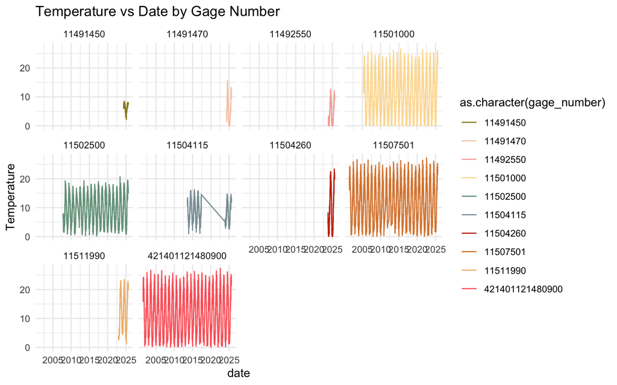

##### Date range summary

```
#> # A tibble: 10 × 4
#>    gage_number     min_date   max_date   record_count
#>    <chr>           <date>     <date>            <int>
#>  1 11491450        2024-05-07 2025-08-25          476
#>  2 11491470        2024-04-13 2025-08-25          500
#>  3 11492550        2023-11-30 2025-08-25          635
#>  4 11501000        2005-04-28 2025-08-25         7410
#>  5 11502500        2007-10-17 2025-08-25         6251
#>  6 11504115        2013-08-01 2025-08-25         2024
#>  7 11504260        2023-10-27 2025-08-25          665
#>  8 11507501        2001-06-16 2025-08-13         8247
#>  9 11511990        2022-12-15 2025-08-25          939
#> 10 421401121480900 2001-06-16 2025-08-13         8640
```

### USGS - Lake Levels elevation in ft

### Date coverage

Note that there are two gages (11505900 and 11505800) that have significantly lower lake levels pre September 1986. Look at raw script for more details.

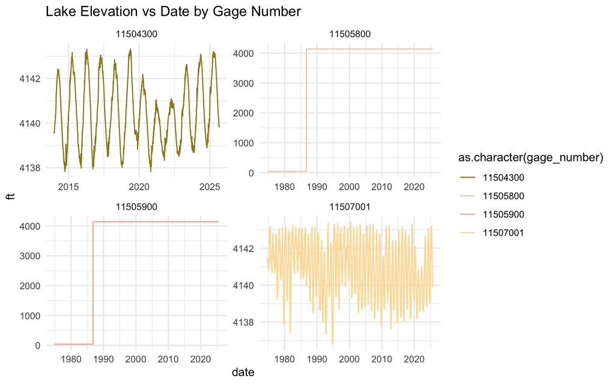

Filtering years after Sept 1986 for the two gages

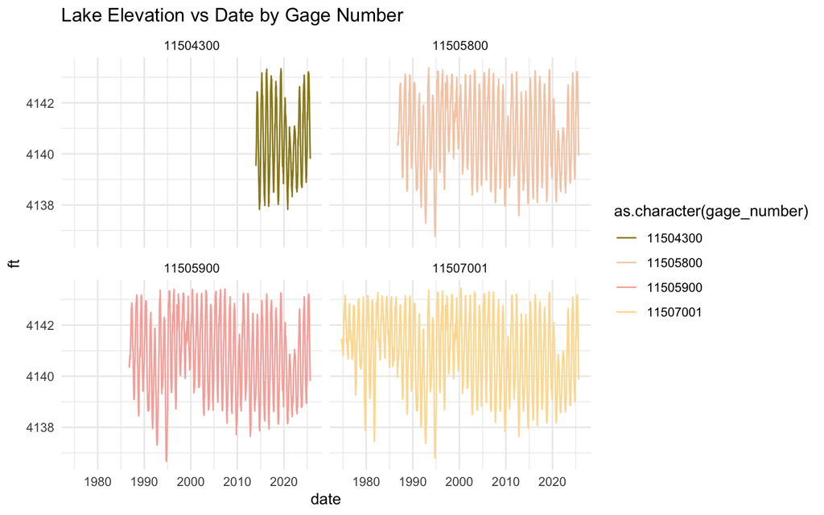

##### Date range summary - original data, not cropped

```
#> # A tibble: 4 × 4
#>   gage_number min_date   max_date   record_count
#>   <chr>       <date>     <date>            <int>
#> 1 11504300    2013-12-24 2025-08-25         4254
#> 2 11505800    1974-09-30 2025-08-25        18419
#> 3 11505900    1974-09-30 2025-08-25        18478
#> 4 11507001    1974-10-01 2025-08-25        18586
```